# R Notebook

```r
library(dplyr)
```

# Sustancias Legales

## E - tabaco

### el ultimo mes (días)

```r
# Se borran los registros de "no aplica"
nna <- C_e%>% filter(E_06 != 0)
sum(nna$E_06 == "99") # cuantas personas no contestaron
nna <- nna %>% filter(E_06 != "99")
nrow(nna)
```

```r
boxplot(nna$E_06)
hist(nna$E_06)
quantile(nna$E_06, probs = 0.25)
```

Todo aquel que consuma mas de 8 días en el ultimo mes

### diarimente

```r
# Se borran los registros de "no aplica"
nna <- C_e %>% filter(E_09 != "0")
nrow(nna)
```

```r
boxplot(nna$E_09)
hist(nna$E_09)
quantile(nna$E_09, probs = 0.25)
```

Cualquier persona que consuma cigarrillo varias veces a la semana se debería considerar consumidor D_08 == “1” o D_08 == “2”

### el ultimo mes (días)

```r
# Se borran los registros de "no aplica"
nna <- C_f%>% filter(F_08 != 0)
sum(nna$F_08 == "99") # cuantas personas no contestaron
nna <- nna %>% filter(F_08 != "99")
nrow(nna)
```

```r
boxplot(nna$F_08)
hist(nna$F_08)
quantile(nna$F_08, probs = 0.25)
```

Todo aquel que consuma mas de 1 días en el ultimo mes se consideraria consumidor??

### el ultimo mes (días) - Embriaguez

```r
# Se borran los registros de "no aplica"
nna <- C_f%>% filter(F_09 != "na")
sum(nna$F_09 == "99") # cuantas personas no contestaron
nna <- nna %>% filter(F_09 != "99") %>% mutate(F_09 = as.numeric(F_09))
nrow(nna)
```

```r
boxplot(nna$F_09)
hist(nna$F_09)
quantile(nna$F_09, probs = 0.25)
```

Aquel que se embriague 0 o mas?? veces al mes se consideraría consumidor

### el ultimo año - Embriaguez

```r
# Se borran los registros de "no aplica"
nna <- C_f%>% filter(F_14 != "na")
nrow(nna)
```

```r
proportions <- as.data.frame(prop.table(table(nna$F_14))); proportions

# Se mira el percentil 75% ya que el gráfico los pone al revés, iniciando por 5 (mas frecuentemente)
ggplot(proportions, aes(x = 1, y = Freq, fill = Var1)) +
  geom_bar(stat = "identity") +
  coord_flip() +
  labs(x = NULL, y = "Proportion")
quantile(as.integer(nna$F_14), 0.25)
```

Todos los que se hayan embriagado **al menos** de la “1”: nunca (“2”: al menos 1 vez al mes), se consideraría consumidor

## H - tranquilizantes

### el ultimo mes (días)

```r
# Se borran los registros de "no aplica"
nna <- C_h%>% filter(H_05 != 0)
sum(nna$H_05 == "99") # cuantas personas no contestaron
nna <- nna %>% filter(H_05 != "99")
nrow(nna)
```

```r
boxplot(nna$H_05)
hist(nna$H_05)
quantile(nna$H_05, probs = 0.25)
```

Se definiría consumidor a aquel que haya consumido medicamentos tranquilizantes mas de dos días en el ultimo mes.

## I - estimulantes

### el ultimo mes (días)

```r
# Se borran los registros de "no aplica"
nna <- C_i%>% filter(I_05 != 0)
sum(nna$I_05 == "99") # cuantas personas no contestaron
nrow(nna)
```

```r
boxplot(nna$I_05)
hist(nna$I_05)
quantile(nna$I_05, probs = 0.25)
```

Se definiría consumidor a aquel que haya consumido medicamentos estimulantes al menos 3 días en el ultimo mes.

## J - inhalables

### el ultimo año - (1)inhalables

```r
# Se borran los registros de "no aplica"
nna <- C_j_1%>% filter(J_03 != "na")
nrow(nna)
```

```r
proportions <- as.data.frame(prop.table(table(nna$J_03))); proportions

# Se mira el percentil 75% ya que el gráfico los pone al revés, iniciando por 5 (mas frecuentemente)
ggplot(proportions, aes(x = 1, y = Freq, fill = Var1)) +
  geom_bar(stat = "identity") +
  coord_flip() +
  labs(x = NULL, y = "Proportion")
quantile(as.integer(nna$J_03), 0.25)
```

Todos los que hayan consumido pegantes/sacol, pinturas, thinner **al menos** de la “2”: Algunas veces durante los últimos 12 meses, se consideraría consumidor

### el ultimo año - (2) DICK, Ladys o fragancia

```r
# Se borran los registros de "no aplica"
nna <- C_j_2%>% filter(J_09 != "na")
nrow(nna)
```

```r
proportions <- as.data.frame(prop.table(table(nna$J_09))); proportions

# Se mira el percentil 75% ya que el gráfico los pone al revés, iniciando por 5 (mas frecuentemente)
ggplot(proportions, aes(x = 1, y = Freq, fill = Var1)) +
  geom_bar(stat = "identity") +
  coord_flip() +
  labs(x = NULL, y = "Proportion")
quantile(as.integer(nna$J_09), 0.25)
```

Todos los que hayan consumido DICK, Ladys o fragancia **al menos** de la “1”: Una sola vez, se consideraría consumidor

### (3) Popper

Para los que respondieron que habían consumido popper alguna vez en su vida solo se les pregunta si han consumido el ultimo año y si han consumido en los últimos 30 días, con posible respuestas: si, no y no contesta

## K - marihuana

### el ultimo año

```r
nna <- C_k%>% filter(K_04 != "na")
sum(nna$K_04 == "9") # cuantas personas no contestaron
```

```
[1] 13
```

```r
nna <- nna %>% filter(K_04 != "9")
nrow(nna)
```

```
[1] 1210
```

| Var1 | Freq |
| --- | --- |
| 1 | 0.1198347 |
| 2 | 0.2495868 |
| 3 | 0.1710744 |
| 4 | 0.1785124 |
| 5 | 0.2809917 |

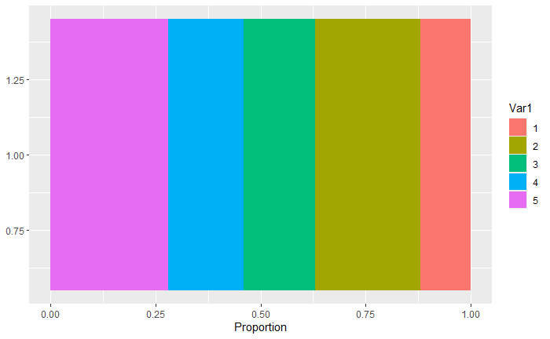

```r
proportions <- as.data.frame(prop.table(table(nna$K_04))); proportions


# Se mira el percentil 75% ya que el gráfico los pone al revés, iniciando por 5 (mas frecuentemente)
ggplot(proportions, aes(x = 1, y = Freq, fill = Var1)) +
  geom_bar(stat = "identity") +
  coord_flip() +
  labs(x = NULL, y = "Proportion")
```

```r
quantile(as.integer(nna$K_04), 0.25)
```

```
25%
  2
```

Todos los que hayan consumido **al menos** de la “2”: Algunas veces durante los últimos 12 meses, se consideraría consumidor

### el ultimo mes (días)

```r
# Se borran los registros de "no aplica"
nna <- C_k%>% filter(K_06 != 0)
sum(nna$K_06 == "99") # cuantas personas no contestaron
nna <- nna %>% filter(K_06 != "99")
nrow(nna)
```

```r
boxplot(nna$K_06)
hist(nna$K_06)
quantile(nna$K_06, probs = 0.25)
```

Aquellos que consuman mas de 4 días en el ultimo mes se considerarían consumidores.

### el ultimo mes (cuantos)

```r
# Se borran los registros de "no aplica"
nna <- C_k%>% filter(K_08 != 0)
nrow(nna)
```

```r
boxplot(nna$K_08)
hist(nna$K_08)
quantile(nna$K_08, probs = 0.25)
```

## L - cocaína

### el ultimo año

```r
# Se borran los registros de "no aplica"
nna <- C_l%>% filter(L_03 != "na")
sum(nna$L_03 == "9") # cuantas personas no contestaron
nna <- nna %>% filter(L_03 != "9")
nrow(nna)
```

```r
proportions <- as.data.frame(prop.table(table(nna$L_03))); proportions

# Se mira el percentil 75% ya que el gráfico los pone al revés, iniciando por 5 (mas frecuentemente)
ggplot(proportions, aes(x = 1, y = Freq, fill = Var1)) +
  geom_bar(stat = "identity") +
  coord_flip() +
  labs(x = NULL, y = "Proportion")
quantile(as.integer(nna$L_03), 0.25)
```

Todos los que hayan consumido **al menos** de la “2”: Algunas veces durante los últimos 12 meses, se consideraría consumidor

### el ultimo mes (días)

```r
# Se borran los registros de "no aplica"
nna <- C_l%>% filter(L_05 != 0)
sum(nna$L_05 == "99") # cuantas personas no contestaron
nna <- nna %>% filter(L_05 != "99")
nrow(nna)
```

```r
boxplot(nna$L_05)
hist(nna$L_05)
quantile(nna$L_05, probs = 0.25)
```

Se consideraría consumidor a aquellos que hayan consumido al menos 2 días en el ultimo mes.

### el ultimo mes (cuantos)

```r
# Se borran los registros de "no aplica"
nna <- C_l%>% filter(L_07 != 0)
nrow(nna)
```

```r
boxplot(nna$L_07)
hist(nna$L_07)
quantile(nna$L_07, probs = 0.25)
```

## M - basuco

### en el ultimo año

```r
# Se borran los registros de "no aplica"
nna <- C_m%>% filter(M_03 != "na")
sum(nna$M_03 == "9") # cuantas personas no contestaron
nna <- nna %>% filter(M_03 != "9")
nrow(nna)
```

```r
proportions <- as.data.frame(prop.table(table(nna$M_03))); proportions

# Se mira el percentil 75% ya que el gráfico los pone al revés, iniciando por 5 (mas frecuentemente)
ggplot(proportions, aes(x = 1, y = Freq, fill = Var1)) +
  geom_bar(stat = "identity") +
  coord_flip() +
  labs(x = NULL, y = "Proportion")
quantile(as.integer(nna$M_03), 0.25)
```

Todos los que hayan consumido **al menos** de la “2”: Algunas veces durante los últimos 12 meses, se consideraría consumidor

### el ultimo mes (días)

```r
# Se borran los registros de "no aplica"
nna <- C_m%>% filter(M_05 != 0)
sum(nna$M_05 == "99") # cuantas personas no contestaron
nna <- nna %>% filter(M_05 != "99")
nrow(nna)
```

```r
boxplot(nna$M_05)
hist(nna$M_05)
quantile(nna$M_05, probs = 0.25)
```

Se consideraria consumidor a aquellos que hayan consumido al menos 3 dias en el ultimo mes.

### el ultimo mes (cuantos)

```r
# Se borran los registros de "no aplica"
nna <- C_m%>% filter(M_07 != 0)
nrow(nna)
```

```r
boxplot(nna$M_07)
hist(nna$M_07)
quantile(nna$M_07, probs = 0.25)
```

## N - extasis

### en el ultimo año

```r
# Se borran los registros de "no aplica"
nna <- C_n%>% filter(N_03 != "na")
sum(nna$N_03 == "9") # cuantas personas no contestaron
nna <- nna %>% filter(N_03 != "9")
nrow(nna)
```

```r
proportions <- as.data.frame(prop.table(table(nna$N_03))); proportions

# Se mira el percentil 75% ya que el gráfico los pone al revés, iniciando por 5 (mas frecuentemente)
ggplot(proportions, aes(x = 1, y = Freq, fill = Var1)) +
  geom_bar(stat = "identity") +
  coord_flip() +
  labs(x = NULL, y = "Proportion")
quantile(as.integer(nna$N_03), 0.25)
```

Todos los que hayan consumido **al menos?** de la “1”: Una sola vez, se consideraría consumidor

### el ultimo mes (días)

```r
# Se borran los registros de "no aplica"
nna <- C_n%>% filter(N_05 != 0)
sum(nna$N_05 == "99") # cuantas personas no contestaron
nna <- nna %>% filter(N_05 != "99")
nrow(nna)
```

```r
boxplot(nna$N_05)
hist(nna$N_05)
quantile(nna$N_05, probs = 0.25)
```

Se consideraría consumidor a aquellos que hayan consumido al menos 1 día en el ultimo mes.

### maximo por dia

```r
# Se borran los registros de "no aplica"
nna <- C_n%>% filter(N_07 != 0)
nrow(nna)
```

```r
boxplot(nna$N_07)
hist(nna$N_07)
quantile(nna$N_07, probs = 0.25)
```

## O - heroína

### en el ultimo año

```r
# Se borran los registros de "no aplica"
nna <- C_o%>% filter(O_03 != "na")
sum(nna$O_03 == "9") # cuantas personas no contestaron
nna <- nna %>% filter(O_03 != "9")
nrow(nna)
```

```r
proportions <- as.data.frame(prop.table(table(nna$O_03))); proportions

# Se mira el percentil 75% ya que el gráfico los pone al revés, iniciando por 5 (mas frecuentemente)
ggplot(proportions, aes(x = 1, y = Freq, fill = Var1)) +
  geom_bar(stat = "identity") +
  coord_flip() +
  labs(x = NULL, y = "Proportion")
quantile(as.integer(nna$O_03), 0.25)
```

Todos los que hayan consumido **al menos** de la “1”: Una sola vez, se consideraría consumidor

### el ultimo mes (días)

```r
# Se borran los registros de "no aplica"
nna <- C_o%>% filter(O_06 != 0)
sum(nna$O_06 == "99") # cuantas personas no contestaron
nna <- nna %>% filter(O_06 != "99")
nrow(nna)
```

```r
boxplot(nna$O_06)
hist(nna$O_06)
quantile(nna$O_06, probs = 0.25)
```

Aquellos que hayan consumido al menos 5 dias en el ultimo mes se consideraria consumidor.

### el ultimo mes (cuantos)

```r
# Se borran los registros de "no aplica"
nna <- C_o%>% filter(O_08 != 0)
nrow(nna)
```

```r
boxplot(nna$O_08)
hist(nna$O_08)
quantile(nna$O_08, probs = 0.25)
```

## P - otras

### Opiodes

```r
sum(C_p1$P_01 == "9") # cuantas personas no contestaron
nna <- C_p1 %>% filter(P_01 != "9")
nrow(nna)

proportions <- as.data.frame(prop.table(table(nna$P_01))); proportions
```

```r
# Se borran los registros de "no aplica"
nna <- C_p1%>% filter(P_02 != "na")
sum(nna$P_02 == "9") # cuantas personas no contestaron
nna <- nna %>% filter(P_02 != "9")
nrow(nna)

proportions <- as.data.frame(prop.table(table(nna$P_02))); proportions
```

### LSD

```r
sum(C_p2$P_03 == "9") # cuantas personas no contestaron
nna <- C_p2 %>% filter(P_03 != "9")
nrow(nna)

proportions <- as.data.frame(prop.table(table(nna$P_03))); proportions
```

```r
# Se borran los registros de "no aplica"
nna <- C_p2%>% filter(P_04 != "na")
sum(nna$P_04 == "9") # cuantas personas no contestaron
nna <- nna %>% filter(P_04 != "9")
nrow(nna)

proportions <- as.data.frame(prop.table(table(nna$P_04))); proportions
```

### Hongo - Yage - Cacao Sabanero

```r
sum(C_p3$P_05 == "9") # cuantas personas no contestaron
nna <- C_p3 %>% filter(P_05 != "9")
nrow(nna)

proportions <- as.data.frame(prop.table(table(nna$P_05))); proportions
```

```r
# Se borran los registros de "no aplica"
nna <- C_p3%>% filter(P_06 != "na")
sum(nna$P_06 == "9") # cuantas personas no contestaron
nna <- nna %>% filter(P_06 != "9")
nrow(nna)

proportions <- as.data.frame(prop.table(table(nna$P_06))); proportions
```